# Risk Factor Analysis

## Outcome Variable

**Outcome Variable:** ever_co

## Predictor Variables

**Intervention Variable:** exclfeed3

**Adjustment Set:**

- arm
- sex
- brthmon
- W_mage
- meducyrs
- feducyrs
- hhwealth_quart
- hfoodsec
- W_mhtcm
- W_mwtkg
- W_mbmi
- vagbrth
- W_gagebrth
- W_birthwt
- W_birthlen
- W_nrooms
- W_nchldlt5
- month
- W_parity
- impfloor
- impsan
- safeh20
- delta_W_mage
- delta_meducyrs
- delta_feducyrs
- delta_hhwealth_quart
- delta_hfoodsec
- delta_W_mhtcm
- delta_W_mwtkg
- delta_W_mbmi
- delta_vagbrth
- delta_W_gagebrth
- delta_W_birthwt
- delta_W_birthlen
- delta_W_nrooms
- delta_W_nchldlt5
- delta_month
- delta_W_parity
- delta_impfloor
- delta_impsan
- delta_safeh20

## Stratifying Variables

The analysis was stratified on these variable(s):

- agecat
- studyid
- country

## Data Summary

| agecat | studyid | country | exclfeed3 | ever_co | n_cell | n |
| --- | --- | --- | --- | --- | --- | --- |
| 0-24 months | CMC-V-BCS-2002 | INDIA | 1 | 0 | 7 | 10 |
| 0-24 months | CMC-V-BCS-2002 | INDIA | 1 | 1 | 3 | 10 |
| 0-24 months | CMC-V-BCS-2002 | INDIA | 0 | 0 | 0 | 10 |
| 0-24 months | CMC-V-BCS-2002 | INDIA | 0 | 1 | 0 | 10 |
| 0-24 months | EE | PAKISTAN | 1 | 0 | 17 | 39 |
| 0-24 months | EE | PAKISTAN | 1 | 1 | 22 | 39 |
| 0-24 months | EE | PAKISTAN | 0 | 0 | 0 | 39 |
| 0-24 months | EE | PAKISTAN | 0 | 1 | 0 | 39 |
| 0-24 months | GMS-Nepal | NEPAL | 1 | 0 | 247 | 458 |
| 0-24 months | GMS-Nepal | NEPAL | 1 | 1 | 133 | 458 |
| 0-24 months | GMS-Nepal | NEPAL | 0 | 0 | 54 | 458 |
| 0-24 months | GMS-Nepal | NEPAL | 0 | 1 | 24 | 458 |
| 0-24 months | IRC | INDIA | 1 | 0 | 0 | 10 |
| 0-24 months | IRC | INDIA | 1 | 1 | 0 | 10 |
| 0-24 months | IRC | INDIA | 0 | 0 | 9 | 10 |
| 0-24 months | IRC | INDIA | 0 | 1 | 1 | 10 |
| 0-24 months | JiVitA-3 | BANGLADESH | 1 | 0 | 12291 | 14981 |
| 0-24 months | JiVitA-3 | BANGLADESH | 1 | 1 | 1267 | 14981 |
| 0-24 months | JiVitA-3 | BANGLADESH | 0 | 0 | 1290 | 14981 |
| 0-24 months | JiVitA-3 | BANGLADESH | 0 | 1 | 133 | 14981 |
| 0-24 months | JiVitA-4 | BANGLADESH | 1 | 0 | 132 | 165 |
| 0-24 months | JiVitA-4 | BANGLADESH | 1 | 1 | 16 | 165 |
| 0-24 months | JiVitA-4 | BANGLADESH | 0 | 0 | 13 | 165 |
| 0-24 months | JiVitA-4 | BANGLADESH | 0 | 1 | 4 | 165 |
| 0-24 months | Keneba | GAMBIA | 1 | 0 | 1515 | 2019 |
| 0-24 months | Keneba | GAMBIA | 1 | 1 | 284 | 2019 |
| 0-24 months | Keneba | GAMBIA | 0 | 0 | 163 | 2019 |
| 0-24 months | Keneba | GAMBIA | 0 | 1 | 57 | 2019 |
| 0-24 months | MAL-ED | BANGLADESH | 1 | 0 | 132 | 244 |
| 0-24 months | MAL-ED | BANGLADESH | 1 | 1 | 27 | 244 |

[output cut: 162 more lines]

The following strata were considered:

- agecat: 0-24 months, studyid: CMC-V-BCS-2002, country: INDIA
- agecat: 0-24 months, studyid: EE, country: PAKISTAN
- agecat: 0-24 months, studyid: GMS-Nepal, country: NEPAL
- agecat: 0-24 months, studyid: IRC, country: INDIA
- agecat: 0-24 months, studyid: JiVitA-3, country: BANGLADESH
- agecat: 0-24 months, studyid: JiVitA-4, country: BANGLADESH
- agecat: 0-24 months, studyid: Keneba, country: GAMBIA
- agecat: 0-24 months, studyid: MAL-ED, country: BANGLADESH
- agecat: 0-24 months, studyid: MAL-ED, country: BRAZIL
- agecat: 0-24 months, studyid: MAL-ED, country: INDIA
- agecat: 0-24 months, studyid: MAL-ED, country: NEPAL
- agecat: 0-24 months, studyid: MAL-ED, country: PERU
- agecat: 0-24 months, studyid: MAL-ED, country: SOUTH AFRICA
- agecat: 0-24 months, studyid: MAL-ED, country: TANZANIA, UNITED REPUBLIC OF
- agecat: 0-24 months, studyid: PROVIDE, country: BANGLADESH
- agecat: 0-24 months, studyid: SAS-CompFeed, country: INDIA
- agecat: 0-6 months, studyid: CMC-V-BCS-2002, country: INDIA
- agecat: 0-6 months, studyid: EE, country: PAKISTAN
- agecat: 0-6 months, studyid: GMS-Nepal, country: NEPAL
- agecat: 0-6 months, studyid: IRC, country: INDIA
- agecat: 0-6 months, studyid: JiVitA-3, country: BANGLADESH
- agecat: 0-6 months, studyid: JiVitA-4, country: BANGLADESH
- agecat: 0-6 months, studyid: Keneba, country: GAMBIA
- agecat: 0-6 months, studyid: MAL-ED, country: BANGLADESH
- agecat: 0-6 months, studyid: MAL-ED, country: BRAZIL
- agecat: 0-6 months, studyid: MAL-ED, country: INDIA
- agecat: 0-6 months, studyid: MAL-ED, country: NEPAL
- agecat: 0-6 months, studyid: MAL-ED, country: PERU
- agecat: 0-6 months, studyid: MAL-ED, country: SOUTH AFRICA
- agecat: 0-6 months, studyid: MAL-ED, country: TANZANIA, UNITED REPUBLIC OF
- agecat: 0-6 months, studyid: PROVIDE, country: BANGLADESH
- agecat: 0-6 months, studyid: SAS-CompFeed, country: INDIA
- agecat: 6-24 months, studyid: CMC-V-BCS-2002, country: INDIA
- agecat: 6-24 months, studyid: EE, country: PAKISTAN
- agecat: 6-24 months, studyid: GMS-Nepal, country: NEPAL
- agecat: 6-24 months, studyid: IRC, country: INDIA
- agecat: 6-24 months, studyid: JiVitA-3, country: BANGLADESH
- agecat: 6-24 months, studyid: JiVitA-4, country: BANGLADESH
- agecat: 6-24 months, studyid: Keneba, country: GAMBIA
- agecat: 6-24 months, studyid: MAL-ED, country: BANGLADESH
- agecat: 6-24 months, studyid: MAL-ED, country: BRAZIL
- agecat: 6-24 months, studyid: MAL-ED, country: INDIA
- agecat: 6-24 months, studyid: MAL-ED, country: NEPAL
- agecat: 6-24 months, studyid: MAL-ED, country: PERU
- agecat: 6-24 months, studyid: MAL-ED, country: SOUTH AFRICA
- agecat: 6-24 months, studyid: MAL-ED, country: TANZANIA, UNITED REPUBLIC OF
- agecat: 6-24 months, studyid: PROVIDE, country: BANGLADESH
- agecat: 6-24 months, studyid: SAS-CompFeed, country: INDIA

### Dropped Strata

Some strata were dropped due to rare outcomes:

- agecat: 0-24 months, studyid: CMC-V-BCS-2002, country: INDIA
- agecat: 0-24 months, studyid: EE, country: PAKISTAN
- agecat: 0-24 months, studyid: IRC, country: INDIA
- agecat: 0-24 months, studyid: JiVitA-4, country: BANGLADESH
- agecat: 0-24 months, studyid: MAL-ED, country: BRAZIL
- agecat: 0-24 months, studyid: MAL-ED, country: PERU
- agecat: 0-24 months, studyid: MAL-ED, country: SOUTH AFRICA
- agecat: 0-24 months, studyid: MAL-ED, country: TANZANIA, UNITED REPUBLIC OF
- agecat: 0-6 months, studyid: CMC-V-BCS-2002, country: INDIA
- agecat: 0-6 months, studyid: EE, country: PAKISTAN
- agecat: 0-6 months, studyid: IRC, country: INDIA
- agecat: 0-6 months, studyid: JiVitA-4, country: BANGLADESH
- agecat: 0-6 months, studyid: MAL-ED, country: BANGLADESH
- agecat: 0-6 months, studyid: MAL-ED, country: BRAZIL
- agecat: 0-6 months, studyid: MAL-ED, country: NEPAL
- agecat: 0-6 months, studyid: MAL-ED, country: PERU
- agecat: 0-6 months, studyid: MAL-ED, country: SOUTH AFRICA
- agecat: 0-6 months, studyid: MAL-ED, country: TANZANIA, UNITED REPUBLIC OF
- agecat: 0-6 months, studyid: SAS-CompFeed, country: INDIA
- agecat: 6-24 months, studyid: CMC-V-BCS-2002, country: INDIA
- agecat: 6-24 months, studyid: EE, country: PAKISTAN
- agecat: 6-24 months, studyid: IRC, country: INDIA
- agecat: 6-24 months, studyid: JiVitA-4, country: BANGLADESH
- agecat: 6-24 months, studyid: MAL-ED, country: BRAZIL
- agecat: 6-24 months, studyid: MAL-ED, country: PERU
- agecat: 6-24 months, studyid: MAL-ED, country: SOUTH AFRICA
- agecat: 6-24 months, studyid: MAL-ED, country: TANZANIA, UNITED REPUBLIC OF

## Methods Detail

We’re interested in the causal parameters $E[Y_a]$ for all values of $a \in \mathcal{A}$. These parameters represent the mean outcome if, possibly contrary to fact, we intervened to set all units to have $A=a$. Under the randomization and positivity assumptions, these are identified by the statistical parameters $\psi_a=E_W[E_{Y|A,W}(Y|A=a,W)]$. In addition, we’re interested in the mean of $Y$, $E[Y]$ under no intervention (the observed mean). We will estimate these parameters by using SuperLearner to fit the relevant likelihood factors – $E_{Y|A,W}(Y|A=a,W)$ and $p(A=a|W)$, and then updating our likelihood fit using a joint TMLE.

For unadjusted analyses ($W=\{\}$), initial likelihoods were estimated using Lrnr_glm to estimate the simple $E(Y|A)$ and Lrnr_mean to estimate $p(A)$. For adjusted analyses, a small library containing Lrnr_glmnet, Lrnr_xgboost, and Lrnr_mean was used.

Having estimated these parameters, we will then use the delta method to estimate relative risks and attributable risks relative to a prespecified baseline level of $A$.

# Results Detail

## Results Plots

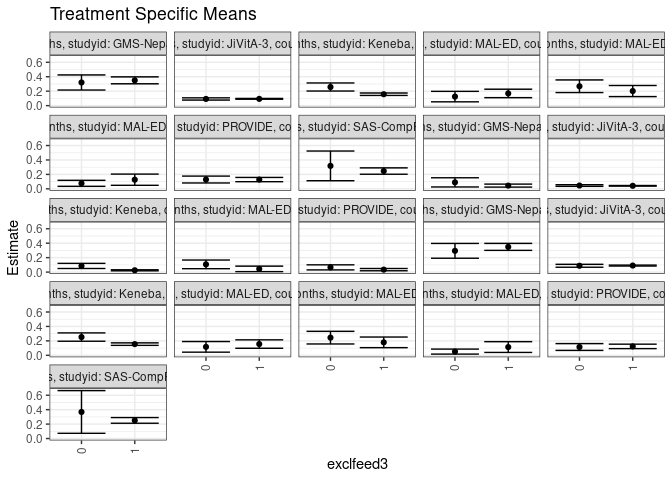

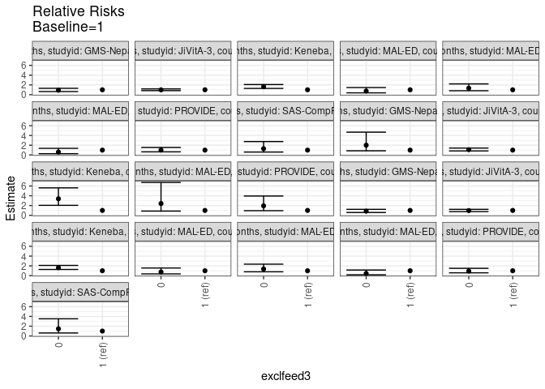

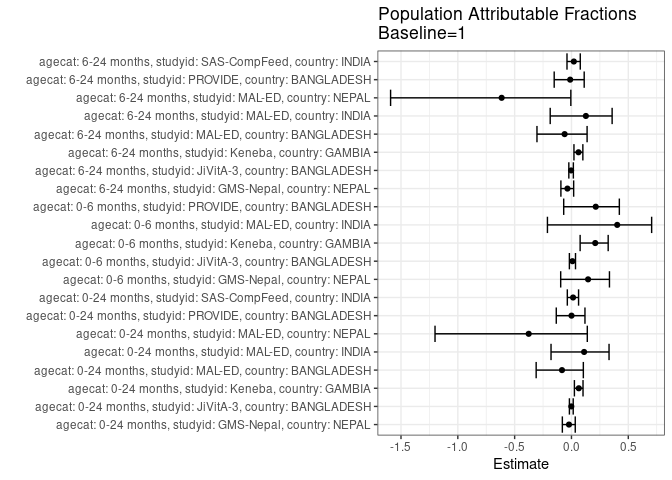

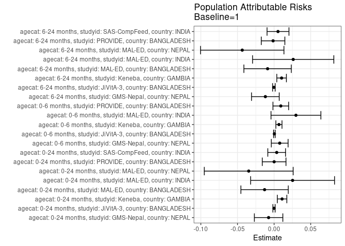

## Results Table

### Parameter: TSM

| agecat | studyid | country | intervention_level | baseline_level | estimate | ci_lower | ci_upper |
| --- | --- | --- | --- | --- | --- | --- | --- |
| 0-24 months | GMS-Nepal | NEPAL | 1 | NA | 0.3503019 | 0.3022242 | 0.3983796 |
| 0-24 months | GMS-Nepal | NEPAL | 0 | NA | 0.3206159 | 0.2161191 | 0.4251127 |
| 0-24 months | JiVitA-3 | BANGLADESH | 1 | NA | 0.0935693 | 0.0882300 | 0.0989086 |
| 0-24 months | JiVitA-3 | BANGLADESH | 0 | NA | 0.0924785 | 0.0769278 | 0.1080292 |
| 0-24 months | Keneba | GAMBIA | 1 | NA | 0.1580008 | 0.1411751 | 0.1748265 |
| 0-24 months | Keneba | GAMBIA | 0 | NA | 0.2577272 | 0.2017724 | 0.3136819 |
| 0-24 months | MAL-ED | BANGLADESH | 1 | NA | 0.1687247 | 0.1099561 | 0.2274933 |
| 0-24 months | MAL-ED | BANGLADESH | 0 | NA | 0.1248812 | 0.0522962 | 0.1974661 |
| 0-24 months | MAL-ED | INDIA | 1 | NA | 0.2015944 | 0.1247860 | 0.2784029 |
| 0-24 months | MAL-ED | INDIA | 0 | NA | 0.2683054 | 0.1809663 | 0.3556445 |
| 0-24 months | MAL-ED | NEPAL | 1 | NA | 0.1267606 | 0.0492016 | 0.2043196 |
| 0-24 months | MAL-ED | NEPAL | 0 | NA | 0.0764331 | 0.0347819 | 0.1180843 |
| 0-24 months | PROVIDE | BANGLADESH | 1 | NA | 0.1285118 | 0.0990457 | 0.1579779 |
| 0-24 months | PROVIDE | BANGLADESH | 0 | NA | 0.1287803 | 0.0811359 | 0.1764247 |
| 0-24 months | SAS-CompFeed | INDIA | 1 | NA | 0.2464455 | 0.2022875 | 0.2906035 |
| 0-24 months | SAS-CompFeed | INDIA | 0 | NA | 0.3181818 | 0.1124254 | 0.5239382 |
| 0-6 months | GMS-Nepal | NEPAL | 1 | NA | 0.0447368 | 0.0239291 | 0.0655446 |
| 0-6 months | GMS-Nepal | NEPAL | 0 | NA | 0.0897436 | 0.0262457 | 0.1532414 |
| 0-6 months | JiVitA-3 | BANGLADESH | 1 | NA | 0.0421491 | 0.0384268 | 0.0458715 |
| 0-6 months | JiVitA-3 | BANGLADESH | 0 | NA | 0.0458843 | 0.0346724 | 0.0570962 |
| 0-6 months | Keneba | GAMBIA | 1 | NA | 0.0250674 | 0.0178466 | 0.0322882 |
| 0-6 months | Keneba | GAMBIA | 0 | NA | 0.0850503 | 0.0496851 | 0.1204155 |
| 0-6 months | MAL-ED | INDIA | 1 | NA | 0.0442478 | 0.0062433 | 0.0822523 |
| 0-6 months | MAL-ED | INDIA | 0 | NA | 0.1067961 | 0.0470114 | 0.1665808 |
| 0-6 months | PROVIDE | BANGLADESH | 1 | NA | 0.0336998 | 0.0178968 | 0.0495029 |
| 0-6 months | PROVIDE | BANGLADESH | 0 | NA | 0.0653567 | 0.0302543 | 0.1004590 |
| 6-24 months | GMS-Nepal | NEPAL | 1 | NA | 0.3489419 | 0.3006237 | 0.3972600 |
| 6-24 months | GMS-Nepal | NEPAL | 0 | NA | 0.2943415 | 0.1916251 | 0.3970580 |
| 6-24 months | JiVitA-3 | BANGLADESH | 1 | NA | 0.0904106 | 0.0839182 | 0.0969031 |
| 6-24 months | JiVitA-3 | BANGLADESH | 0 | NA | 0.0872390 | 0.0672291 | 0.1072489 |
| 6-24 months | Keneba | GAMBIA | 1 | NA | 0.1552091 | 0.1380165 | 0.1724018 |
| 6-24 months | Keneba | GAMBIA | 0 | NA | 0.2527046 | 0.1950076 | 0.3104017 |
| 6-24 months | MAL-ED | BANGLADESH | 1 | NA | 0.1560645 | 0.0974545 | 0.2146745 |
| 6-24 months | MAL-ED | BANGLADESH | 0 | NA | 0.1171039 | 0.0433833 | 0.1908246 |
| 6-24 months | MAL-ED | INDIA | 1 | NA | 0.1796445 | 0.1058662 | 0.2534227 |
| 6-24 months | MAL-ED | INDIA | 0 | NA | 0.2447034 | 0.1573042 | 0.3321026 |
| 6-24 months | MAL-ED | NEPAL | 1 | NA | 0.1142857 | 0.0395884 | 0.1889830 |
| 6-24 months | MAL-ED | NEPAL | 0 | NA | 0.0512821 | 0.0165924 | 0.0859717 |
| 6-24 months | PROVIDE | BANGLADESH | 1 | NA | 0.1235469 | 0.0927982 | 0.1542956 |
| 6-24 months | PROVIDE | BANGLADESH | 0 | NA | 0.1149987 | 0.0679154 | 0.1620820 |
| 6-24 months | SAS-CompFeed | INDIA | 1 | NA | 0.2512563 | 0.2120897 | 0.2904228 |
| 6-24 months | SAS-CompFeed | INDIA | 0 | NA | 0.3684211 | 0.0727072 | 0.6641349 |

### Parameter: E(Y)

| agecat | studyid | country | intervention_level | baseline_level | estimate | ci_lower | ci_upper |
| --- | --- | --- | --- | --- | --- | --- | --- |
| 0-24 months | GMS-Nepal | NEPAL | NA | NA | 0.3427948 | 0.2992779 | 0.3863116 |
| 0-24 months | JiVitA-3 | BANGLADESH | NA | NA | 0.0934517 | 0.0884729 | 0.0984306 |
| 0-24 months | Keneba | GAMBIA | NA | NA | 0.1688955 | 0.1525490 | 0.1852420 |
| 0-24 months | MAL-ED | BANGLADESH | NA | NA | 0.1557377 | 0.1101466 | 0.2013289 |
| 0-24 months | MAL-ED | INDIA | NA | NA | 0.2268519 | 0.1708720 | 0.2828317 |
| 0-24 months | MAL-ED | NEPAL | NA | NA | 0.0921053 | 0.0544873 | 0.1297232 |
| 0-24 months | PROVIDE | BANGLADESH | NA | NA | 0.1285714 | 0.1037574 | 0.1533855 |
| 0-24 months | SAS-CompFeed | INDIA | NA | NA | 0.2500000 | 0.2118239 | 0.2881761 |
| 0-6 months | GMS-Nepal | NEPAL | NA | NA | 0.0524017 | 0.0319714 | 0.0728321 |
| 0-6 months | JiVitA-3 | BANGLADESH | NA | NA | 0.0425304 | 0.0390546 | 0.0460063 |
| 0-6 months | Keneba | GAMBIA | NA | NA | 0.0316989 | 0.0240550 | 0.0393428 |
| 0-6 months | MAL-ED | INDIA | NA | NA | 0.0740741 | 0.0390675 | 0.1090807 |
| 0-6 months | PROVIDE | BANGLADESH | NA | NA | 0.0428571 | 0.0278427 | 0.0578716 |
| 6-24 months | GMS-Nepal | NEPAL | NA | NA | 0.3370288 | 0.2933549 | 0.3807028 |
| 6-24 months | JiVitA-3 | BANGLADESH | NA | NA | 0.0901332 | 0.0839189 | 0.0963475 |
| 6-24 months | Keneba | GAMBIA | NA | NA | 0.1654450 | 0.1487764 | 0.1821136 |
| 6-24 months | MAL-ED | BANGLADESH | NA | NA | 0.1471861 | 0.1013989 | 0.1929734 |
| 6-24 months | MAL-ED | INDIA | NA | NA | 0.2057416 | 0.1508055 | 0.2606778 |
| 6-24 months | MAL-ED | NEPAL | NA | NA | 0.0707965 | 0.0372831 | 0.1043098 |
| 6-24 months | PROVIDE | BANGLADESH | NA | NA | 0.1221498 | 0.0962275 | 0.1480722 |
| 6-24 months | SAS-CompFeed | INDIA | NA | NA | 0.2565947 | 0.2209578 | 0.2922316 |

### Parameter: RR

| agecat | studyid | country | intervention_level | baseline_level | estimate | ci_lower | ci_upper |
| --- | --- | --- | --- | --- | --- | --- | --- |
| 0-24 months | GMS-Nepal | NEPAL | 1 | 1 | 1.0000000 | 1.0000000 | 1.000000 |
| 0-24 months | GMS-Nepal | NEPAL | 0 | 1 | 0.9152560 | 0.6425359 | 1.303730 |
| 0-24 months | JiVitA-3 | BANGLADESH | 1 | 1 | 1.0000000 | 1.0000000 | 1.000000 |
| 0-24 months | JiVitA-3 | BANGLADESH | 0 | 1 | 0.9883421 | 0.8254012 | 1.183449 |
| 0-24 months | Keneba | GAMBIA | 1 | 1 | 1.0000000 | 1.0000000 | 1.000000 |
| 0-24 months | Keneba | GAMBIA | 0 | 1 | 1.6311764 | 1.2829278 | 2.073956 |
| 0-24 months | MAL-ED | BANGLADESH | 1 | 1 | 1.0000000 | 1.0000000 | 1.000000 |
| 0-24 months | MAL-ED | BANGLADESH | 0 | 1 | 0.7401475 | 0.3762263 | 1.456087 |
| 0-24 months | MAL-ED | INDIA | 1 | 1 | 1.0000000 | 1.0000000 | 1.000000 |
| 0-24 months | MAL-ED | INDIA | 0 | 1 | 1.3309169 | 0.8035763 | 2.204321 |
| 0-24 months | MAL-ED | NEPAL | 1 | 1 | 1.0000000 | 1.0000000 | 1.000000 |
| 0-24 months | MAL-ED | NEPAL | 0 | 1 | 0.6029724 | 0.2657429 | 1.368149 |
| 0-24 months | PROVIDE | BANGLADESH | 1 | 1 | 1.0000000 | 1.0000000 | 1.000000 |
| 0-24 months | PROVIDE | BANGLADESH | 0 | 1 | 1.0020894 | 0.6485155 | 1.548434 |
| 0-24 months | SAS-CompFeed | INDIA | 1 | 1 | 1.0000000 | 1.0000000 | 1.000000 |
| 0-24 months | SAS-CompFeed | INDIA | 0 | 1 | 1.2910839 | 0.6050646 | 2.754908 |
| 0-6 months | GMS-Nepal | NEPAL | 1 | 1 | 1.0000000 | 1.0000000 | 1.000000 |
| 0-6 months | GMS-Nepal | NEPAL | 0 | 1 | 2.0060332 | 0.8602153 | 4.678096 |
| 0-6 months | JiVitA-3 | BANGLADESH | 1 | 1 | 1.0000000 | 1.0000000 | 1.000000 |
| 0-6 months | JiVitA-3 | BANGLADESH | 0 | 1 | 1.0886185 | 0.8356614 | 1.418146 |
| 0-6 months | Keneba | GAMBIA | 1 | 1 | 1.0000000 | 1.0000000 | 1.000000 |
| 0-6 months | Keneba | GAMBIA | 0 | 1 | 3.3928671 | 2.0465976 | 5.624724 |
| 0-6 months | MAL-ED | INDIA | 1 | 1 | 1.0000000 | 1.0000000 | 1.000000 |
| 0-6 months | MAL-ED | INDIA | 0 | 1 | 2.4135922 | 0.8657918 | 6.728440 |
| 0-6 months | PROVIDE | BANGLADESH | 1 | 1 | 1.0000000 | 1.0000000 | 1.000000 |
| 0-6 months | PROVIDE | BANGLADESH | 0 | 1 | 1.9393770 | 0.9515138 | 3.952841 |
| 6-24 months | GMS-Nepal | NEPAL | 1 | 1 | 1.0000000 | 1.0000000 | 1.000000 |
| 6-24 months | GMS-Nepal | NEPAL | 0 | 1 | 0.8435260 | 0.5795944 | 1.227645 |
| 6-24 months | JiVitA-3 | BANGLADESH | 1 | 1 | 1.0000000 | 1.0000000 | 1.000000 |
| 6-24 months | JiVitA-3 | BANGLADESH | 0 | 1 | 0.9649196 | 0.7598713 | 1.225299 |
| 6-24 months | Keneba | GAMBIA | 1 | 1 | 1.0000000 | 1.0000000 | 1.000000 |
| 6-24 months | Keneba | GAMBIA | 0 | 1 | 1.6281559 | 1.2657246 | 2.094367 |
| 6-24 months | MAL-ED | BANGLADESH | 1 | 1 | 1.0000000 | 1.0000000 | 1.000000 |
| 6-24 months | MAL-ED | BANGLADESH | 0 | 1 | 0.7503562 | 0.3606318 | 1.561244 |
| 6-24 months | MAL-ED | INDIA | 1 | 1 | 1.0000000 | 1.0000000 | 1.000000 |
| 6-24 months | MAL-ED | INDIA | 0 | 1 | 1.3621538 | 0.7895568 | 2.350006 |
| 6-24 months | MAL-ED | NEPAL | 1 | 1 | 1.0000000 | 1.0000000 | 1.000000 |
| 6-24 months | MAL-ED | NEPAL | 0 | 1 | 0.4487179 | 0.1751721 | 1.149429 |
| 6-24 months | PROVIDE | BANGLADESH | 1 | 1 | 1.0000000 | 1.0000000 | 1.000000 |
| 6-24 months | PROVIDE | BANGLADESH | 0 | 1 | 0.9308102 | 0.5771421 | 1.501203 |
| 6-24 months | SAS-CompFeed | INDIA | 1 | 1 | 1.0000000 | 1.0000000 | 1.000000 |
| 6-24 months | SAS-CompFeed | INDIA | 0 | 1 | 1.4663158 | 0.6118309 | 3.514177 |

### Parameter: PAR

| agecat | studyid | country | intervention_level | baseline_level | estimate | ci_lower | ci_upper |
| --- | --- | --- | --- | --- | --- | --- | --- |
| 0-24 months | GMS-Nepal | NEPAL | 1 | NA | -0.0075072 | -0.0269568 | 0.0119425 |
| 0-24 months | JiVitA-3 | BANGLADESH | 1 | NA | -0.0001176 | -0.0016831 | 0.0014479 |
| 0-24 months | Keneba | GAMBIA | 1 | NA | 0.0108947 | 0.0044433 | 0.0173461 |
| 0-24 months | MAL-ED | BANGLADESH | 1 | NA | -0.0129870 | -0.0453200 | 0.0193460 |
| 0-24 months | MAL-ED | INDIA | 1 | NA | 0.0252574 | -0.0320358 | 0.0825506 |
| 0-24 months | MAL-ED | NEPAL | 1 | NA | -0.0346553 | -0.0953519 | 0.0260413 |
| 0-24 months | PROVIDE | BANGLADESH | 1 | NA | 0.0000596 | -0.0161268 | 0.0162460 |
| 0-24 months | SAS-CompFeed | INDIA | 1 | NA | 0.0035545 | -0.0086130 | 0.0157220 |
| 0-6 months | GMS-Nepal | NEPAL | 1 | NA | 0.0076649 | -0.0038202 | 0.0191500 |
| 0-6 months | JiVitA-3 | BANGLADESH | 1 | NA | 0.0003813 | -0.0007608 | 0.0015235 |
| 0-6 months | Keneba | GAMBIA | 1 | NA | 0.0066315 | 0.0024346 | 0.0108284 |
| 0-6 months | MAL-ED | INDIA | 1 | NA | 0.0298263 | -0.0042119 | 0.0638644 |
| 0-6 months | PROVIDE | BANGLADESH | 1 | NA | 0.0091573 | -0.0016122 | 0.0199269 |
| 6-24 months | GMS-Nepal | NEPAL | 1 | NA | -0.0119130 | -0.0308232 | 0.0069972 |
| 6-24 months | JiVitA-3 | BANGLADESH | 1 | NA | -0.0002774 | -0.0020718 | 0.0015170 |
| 6-24 months | Keneba | GAMBIA | 1 | NA | 0.0102359 | 0.0037224 | 0.0167494 |
| 6-24 months | MAL-ED | BANGLADESH | 1 | NA | -0.0088783 | -0.0412601 | 0.0235034 |
| 6-24 months | MAL-ED | INDIA | 1 | NA | 0.0260972 | -0.0293925 | 0.0815869 |
| 6-24 months | MAL-ED | NEPAL | 1 | NA | -0.0434893 | -0.1004663 | 0.0134878 |
| 6-24 months | PROVIDE | BANGLADESH | 1 | NA | -0.0013971 | -0.0174743 | 0.0146802 |
| 6-24 months | SAS-CompFeed | INDIA | 1 | NA | 0.0053384 | -0.0095993 | 0.0202761 |

### Parameter: PAF

| agecat | studyid | country | intervention_level | baseline_level | estimate | ci_lower | ci_upper |
| --- | --- | --- | --- | --- | --- | --- | --- |
| 0-24 months | GMS-Nepal | NEPAL | 1 | NA | -0.0218999 | -0.0802465 | 0.0332953 |
| 0-24 months | JiVitA-3 | BANGLADESH | 1 | NA | -0.0012582 | -0.0181454 | 0.0153490 |
| 0-24 months | Keneba | GAMBIA | 1 | NA | 0.0645055 | 0.0257801 | 0.1016917 |
| 0-24 months | MAL-ED | BANGLADESH | 1 | NA | -0.0833902 | -0.3106559 | 0.1044680 |
| 0-24 months | MAL-ED | INDIA | 1 | NA | 0.1113389 | -0.1798073 | 0.3306376 |
| 0-24 months | MAL-ED | NEPAL | 1 | NA | -0.3762575 | -1.2005759 | 0.1392776 |
| 0-24 months | PROVIDE | BANGLADESH | 1 | NA | 0.0004638 | -0.1337012 | 0.1187515 |
| 0-24 months | SAS-CompFeed | INDIA | 1 | NA | 0.0142180 | -0.0365627 | 0.0625110 |
| 0-6 months | GMS-Nepal | NEPAL | 1 | NA | 0.1462719 | -0.0948184 | 0.3342717 |
| 0-6 months | JiVitA-3 | BANGLADESH | 1 | NA | 0.0089654 | -0.0183114 | 0.0355116 |
| 0-6 months | Keneba | GAMBIA | 1 | NA | 0.2092025 | 0.0762688 | 0.3230057 |
| 0-6 months | MAL-ED | INDIA | 1 | NA | 0.4026549 | -0.2114697 | 0.7054642 |
| 0-6 months | PROVIDE | BANGLADESH | 1 | NA | 0.2136707 | -0.0683518 | 0.4212452 |
| 6-24 months | GMS-Nepal | NEPAL | 1 | NA | -0.0353473 | -0.0929975 | 0.0192622 |
| 6-24 months | JiVitA-3 | BANGLADESH | 1 | NA | -0.0030779 | -0.0231828 | 0.0166321 |
| 6-24 months | Keneba | GAMBIA | 1 | NA | 0.0618689 | 0.0218862 | 0.1002173 |
| 6-24 months | MAL-ED | BANGLADESH | 1 | NA | -0.0603204 | -0.3035380 | 0.1375169 |
| 6-24 months | MAL-ED | INDIA | 1 | NA | 0.1268444 | -0.1871025 | 0.3577633 |
| 6-24 months | MAL-ED | NEPAL | 1 | NA | -0.6142857 | -1.5915829 | -0.0055315 |
| 6-24 months | PROVIDE | BANGLADESH | 1 | NA | -0.0114373 | -0.1519797 | 0.1119588 |
| 6-24 months | SAS-CompFeed | INDIA | 1 | NA | 0.0208050 | -0.0393691 | 0.0774953 |